# Better Living Through Python

Improving the Bounding Box to SQL Query to Shapefile Export Workflow

Team: 4 TL / Senior Analyst: Whit Miller Analyst: Derek Richardson Reviewer: Robert Kleisley (GA SME)

19 May 2020

# Background

Have you ever wanted to generate a bounding box in Python, take that and query a PostgreSQL database, and then turn those results into a Shapefile to analyze in ArcGIS? Well we did.

# Initial Code Format

What does the code look like, you might ask.

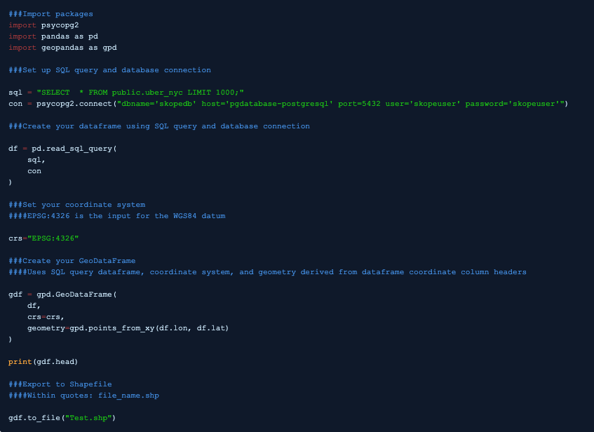

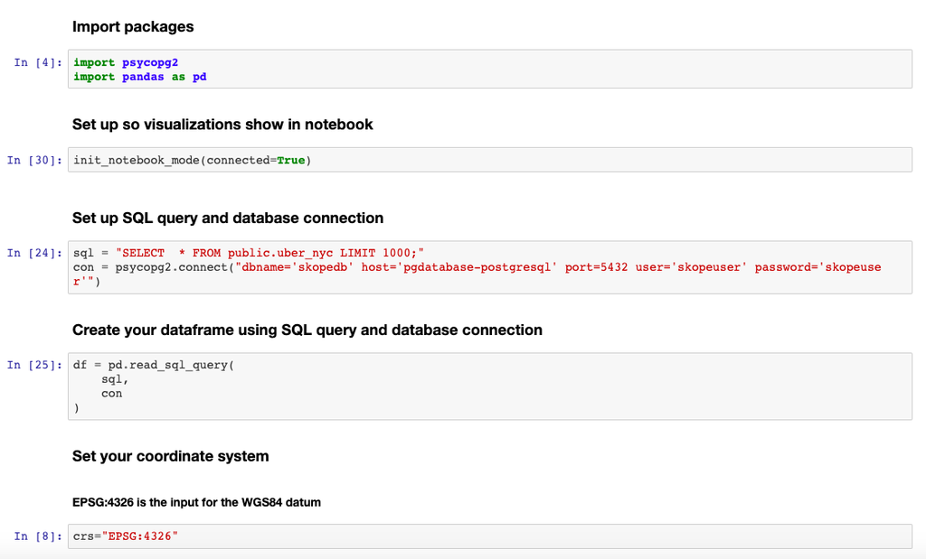

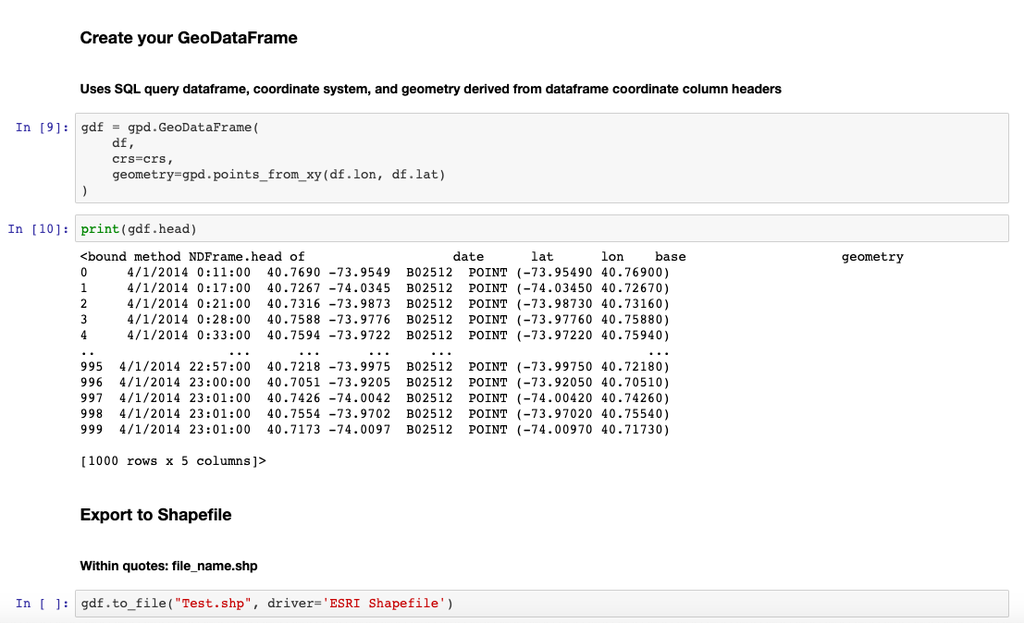

We went for simplicity. Simple because it facilitates easier modification if we need. Simple because our customers have (potentially) even less coding experience than we do. And simple because Whit is very rusty with his Python skills. One thing we stressed is to lay out (in markdown format) in very straightfoward, non-technical terms what each step is having the user do. At the end of the day, we’re trying to teach people how to fish.

# Future Iterations

Is ArcGIS totally necessary, you ask? Well if we asked Erik, Robert, or Breona we’d get a resounding yes. And there’s some truth to that: ArcGIS brings some pretty sweet capabilities to the table. But if we want to simply see where data points plot geospatially, we can have an in-notebook, interactive map. It will hopefully look something like this:

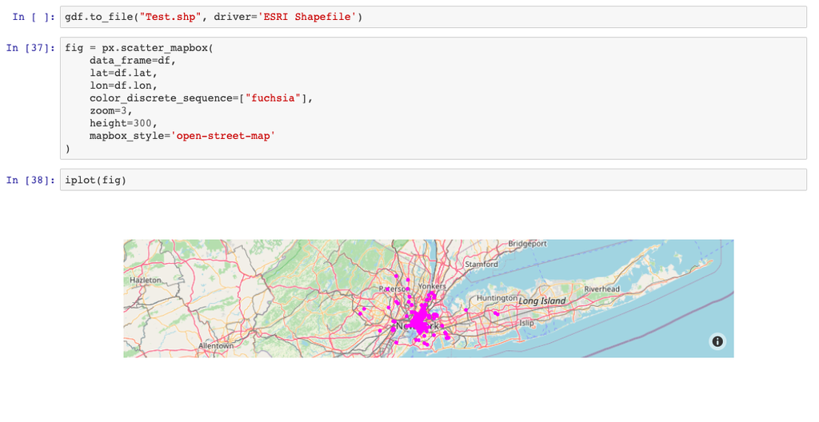